# Rapport_Module_Probabilité

### 2 Échantillons d’exemples :

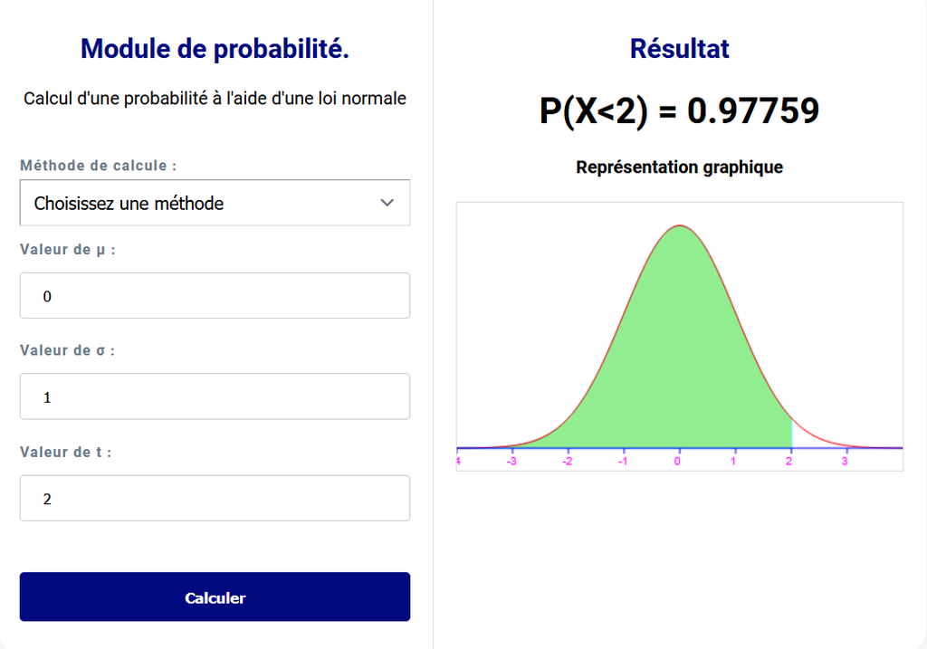

Figure 1

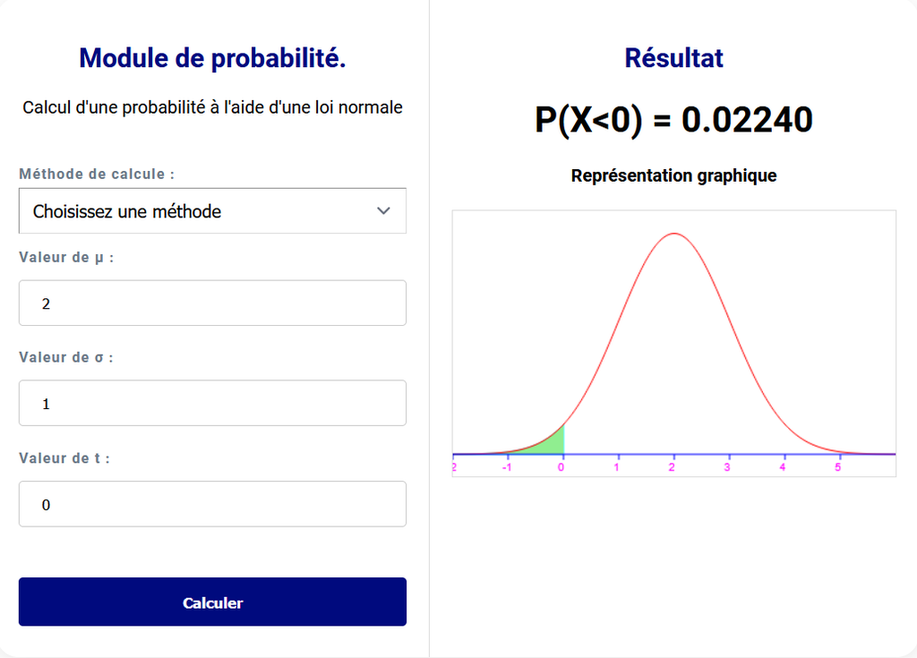

Figure 2

On peut remarquer que 0.97759 + 0.02240 = 0.99999 ~= 1 (cas 1 et 2)

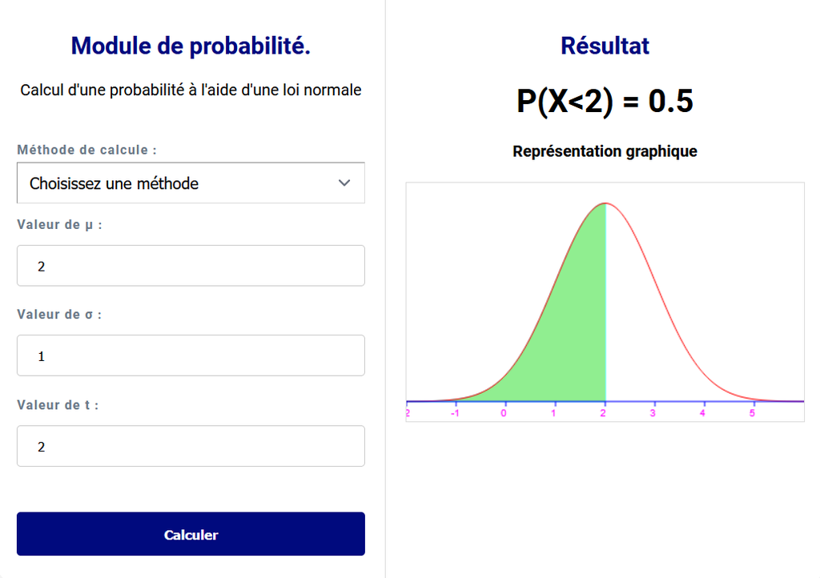

Figure 3 (cas 3 )

Concernant le graphique, nous nous sommes inspirés du code de Alain Busser qu’il a mit sur son site (licence MIT) : https://irem.univ-reunion.fr/IMG/html/normales.html

En résumé, le script va dessiner toujours la même courbe de loi nomrale (courbe de Gauss). Ce qui change d’une courbe à l’autre c’est l’intervale le la courbe qui est représenté tout cela en fonction de t et de µ.